# Some title

```r
library(lingtypology)
library(leaflet.extras)
library(tidyverse)
library(spatstat)
```

### Complexity

Inventory complexity, i.e. the number of elements per subsystem for a number of grammatical subsystems (phonemes, verb inflectional categories, genders, …).

- `overall_complexity_with_roles` – All datapoints on complexity, including the number of core argument roles indexed on the verb.
- `morphological_complexity_with_roles` – Same as above except ony morphological data. This is the measure used e.g. in Bentz, Nichols, & Jäger ALT 2017 workshop paper.

```r
complex <- read_tsv("complexity.csv", skip = 1)
complex <- left_join(complex, autotyp)
complex$Glottocode <- as.character(complex$Glottocode)
complex[c(56, 71), 11] <- c("serb1264", "lazz1240")
complex <- complex[, -1]
complex$language <- lang.gltc(complex$Glottocode)
complex$language[c(35, 87, 105, 166, 204)] <- c("Western Mari", "El Nayar Cora", "Armenian", "Wangaaybuwan-Ngiyambaa", "Kenuzi-Dongola")
complex %>%
  arrange(Overall_complexity) ->
  complex
map.feature(complex$language,
            features = complex$Overall_complexity,
            latitude = complex$Lat,
            longitude = complex$ULong,
            label = complex$language,
            title = "Overall complexity",
            color = c("white", "lightblue", "black")) %>%
  addFullscreenControl()
```

[interactive chart not shown]

```r
complex %>%
  arrange(Morphological_complexity) ->
  complex

map.feature(complex$language,
            complex$Morphological_complexity,
            latitude = complex$Lat,
            longitude = complex$ULong,
            label = complex$language,
            title = "Morphological complexity",
            color = c("white", "lightblue", "black")) %>%
  addFullscreenControl()
```

[interactive chart not shown]

### Person

Lexical and inflectional points (on a questionnaire where each item identifies a pattern or behavior of the category of person as to whether it is inflectional or lexical). Entries are total points per language, and percentages (calculated only when total for each is over 2 points).

```r
person <- read_tsv("person.csv", skip = 1)
person <- left_join(person, autotyp)
person$language2 <- lang.gltc(person$Glottocode)

person$language2[which(is.na(person$language2))] <- c(
  "Kenuzi-Dongola", # Dongolese Nubian
  "Central Kanuri", # Kanuri
  "Laz", # Laz (Pazar)
  "Armenian", # E. Armenian
  "Western Mari", # Mari
  "Aka-Kede", # Great Andamanese
  "Atampaya", # Uradhi
  "El Nayar Cora", # Cora
  "Asheninka Perene"# Alto Perené
)

person %>%
  arrange(Lex) ->
  person

map.feature(person$language2,
            latitude = person$lat,
            longitude = person$long,
            label = person$language2,
            features = person$Lex,
            color = c("white", "lightblue", "black"),
            title = "person Lex")
```

[interactive chart not shown]

```r
person %>%
  arrange(Infl) ->
  person

map.feature(person$language2,
            latitude = person$lat,
            longitude = person$long,
            label = person$language2,
            features = person$Infl,
            color = c("white", "lightblue", "black"),
            title = "person Infl") %>%
  addFullscreenControl()
```

[interactive chart not shown]

### Causativization

Percent of a 9-item verb pair list where the causal (=semantic causative) member of the pair is derived.

```r
caus <- read_tsv("causative.csv", skip = 1)

caus <- left_join(caus, autotyp)
caus$language2 <- lang.gltc(caus$Glottocode)
caus$language2[c(7, 13, 15, 19, 30, 82, 113, 115, 139, 176, 205)] <-
  c("Central Kanuri",
    "Kenuzi-Dongola",
    "South-Central Kikongo",
    "Soga",
    "Armenian",
    "Western Mari",
    "Russia Buriat",
    "Halh Mongolian",
    "Aka-Kede",
    "Central Ojibwa",
    "Serbian")

caus %>%
  arrange(`% Cs`) ->
  caus

map.feature(caus$language2,
            latitude = caus$lat,
            longitude = caus$long,
            label = paste(caus$language, round(caus$`% Cs`, 2)),
            features = caus$`% Cs`,
            color = c("white", "lightblue", "black"),
            title = "% Cs") %>%
  addFullscreenControl()
```

[interactive chart not shown]

### Inclusive/exclusive

Presence vs. absence of inclusive/exclusive opposition. Data from Autotyp database.

```r
incl_excl <- read_tsv("excl_incl.csv", skip = 1)
incl_excl <- left_join(incl_excl, autotyp)
incl_excl$language2 <- lang.gltc(incl_excl$Glottocode)
#incl_excl$language2[c(22, 26, 35, 40, 56, 63, 86, 136, 137, 138, 139, 144, 151, 174, 203, 213, 307, 354, 387, 425)] <-
incl_excl$language2[c(which(is.na(incl_excl$language2)),
                      which(is.na(incl_excl$LID)))] <-
  c("Armenian", # "Armenian (Eastern)",
    "Asheninka Perene", # "Ashéninka Perené"
    "Central Moroccan Berber", # "Berber"
    "Futuna-Aniwa", # Futuna (West)
    "Aka-Kede", # "Great Andamanese"
    "Central Grebo", # "Grebo"
    "Gurung", # "Gurung"
    "Central Kanuri", # "Kanuri"
    "Plateau Malagasy", # "Malagasy"
    "Western Mari", # "Mari"
    "Totontepec Mixe", # "Mixe"
    "Wangaaybuwan-Ngiyambaa", # "Ngiyambaa"
    "Kenuzi-Dongola",  # Nubian (Dongolese)
    "Central Ojibwa", # "Ojibwa"
    "Atampaya", # "Uradhi"
    "Obdorsk Khanty", # "Khanty"
    "Manchu", # "Manchu"
    "Nganasan", # "Nganasan"
    "Udihe", # "Udehe"
    "Sakha") # "Yakut")

incl_excl %>%
  arrange(desc(ie_type)) ->
  incl_excl

map.feature(incl_excl$language2,
            latitude = incl_excl$lat,
            longitude = incl_excl$long,
            popup = incl_excl$source,
            label = incl_excl$language,
            features = incl_excl$ie_type,
            title = "inclusive/exclusive opposition",
            color = c("tomato",
                      "darkgreen",
                      "lightgrey",
                      "lightseagreen")) %>%
  addFullscreenControl()
```

[interactive chart not shown]

### Noun- and verb-based

% of items on a 50-word list that have noun vs. verb as base of the derivational paradigm.

#### 5.1.1 % N/all

```r
NV <- read_tsv("N-V.csv", skip = 1)

NV <- left_join(NV, autotyp)
NV$language2 <- lang.gltc(NV$Glottocode)
NV$language2[c(1,3,11,19)] <- c("Central Kanuri",
                                "Kenuzi-Dongola",
                                "Upper Sorbian",
                                "Western Mari")

NV %>%
  arrange(`% N/all`) ->
  NV

map.feature(NV$language2,
            latitude = NV$lat,
            longitude = NV$ulong,
            label = paste(NV$language, round(NV$`% N/all`, 2)),
            features = NV$`% N/all`,
            color = c("white", "lightblue", "black"),
            title = "% N/all") %>%
  addFullscreenControl()
```

[interactive chart not shown]

#### 5.1.2 % V/all

```r
NV %>%
  arrange(`% V/all`) ->
  NV

map.feature(NV$language2,
            latitude = NV$lat,
            longitude = NV$ulong,
            label = paste(NV$language, round(NV$`% V/all`, 2)),
            features = NV$`% V/all`,
            color = c("white", "lightblue", "black"),
            title = "% V/all") %>%
  addFullscreenControl()
```

[interactive chart not shown]

#### 5.1.3 % Flex/all

```r
NV %>%
  arrange(`% Flex/all`) ->
  NV

map.feature(NV$language2,
            latitude = NV$lat,
            longitude = NV$ulong,
            label = paste(NV$language, round(NV$`% Flex/all`, 2)),
            features = NV$`% Flex/all`,
            color = c("white", "lightblue", "black"),
            title = "% Flex/all") %>%
  addFullscreenControl()
```

[interactive chart not shown]

#### 5.2.1 Nearest neighbour

```r
data.frame(nn = nndist(NV[, 3:4], k = 1)) %>%
  mutate(language = NV$language) %>%
  arrange(nn) %>%
  mutate(id = 1:nrow(NV),
         type = "our dataset") ->
  nn_df
```

Compare nearest neighbour for our dataset and the whole glottolog database in `lingtypology`:

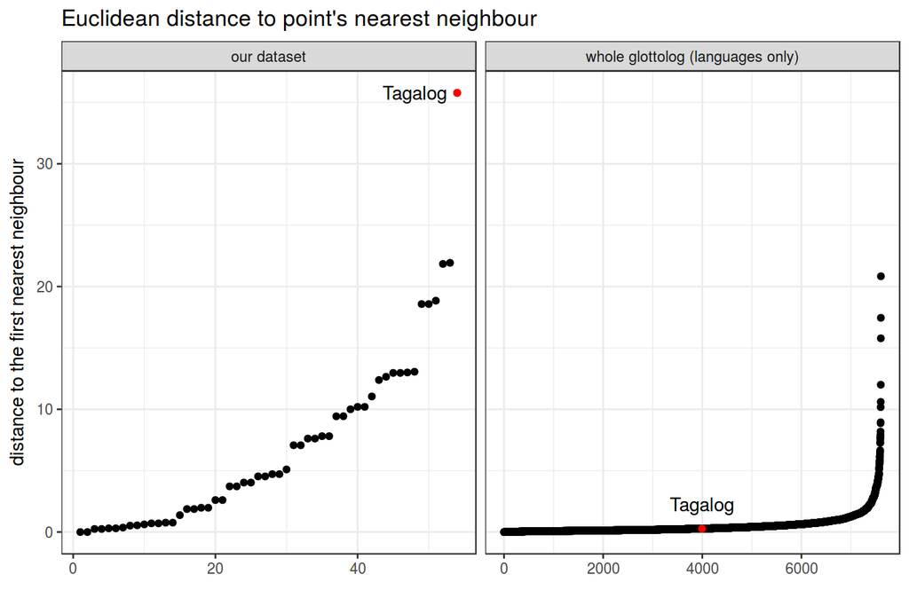

```r
data.frame(nn = nndist(na.omit(glottolog.modified[,4:5]), k = 1)) %>%
  mutate(language = glottolog.modified[!is.na(glottolog.modified$longitude),]$language) %>%
  arrange(nn) %>%
  mutate(id = 1:nrow(na.omit(glottolog.modified[,4:5])),
         type = "whole glottolog (languages only)") ->
  nn_glottolog

nn_glottolog %>%
  rbind(nn_df) %>%
  ggplot(aes(id, nn))+
  geom_point()+
  theme_bw()+
  labs(x = "", y = "distance to the first nearest neighbour",
       title = "Euclidean distance to point's nearest neighbour")+
  facet_wrap(~type, scale = "free_x")+
  geom_text(data = nn_df[nrow(nn_df),],
            aes(x = id - 6, label = language))+
  geom_text(data = nn_glottolog[nn_glottolog$language == last(nn_df$language),],
            aes(y = nn+2, label = language))+
  geom_point(data = nn_df[nrow(nn_df),], color = "red")+
  geom_point(data = nn_glottolog[nn_glottolog$language == last(nn_df$language),],
             color = "red")
```

This graph shows that Tagalog point have the unnormally big distance to the nearest neighbour. So the cluster with Tagalog is underrepresent in our data. We need to keep it in mind. Other clusters are underrepresented too. We can color points by group or by area and that will show us which of the area or the language group is overrepresented and which is underrepresented in our sample (from areal poiint of view). We could calculate not only the first nearest neighbour, but also the second, the third etc.

### Opacity

Opacity (vs. transparency) (a.k.a. Canonical Complexity)

```r
read_csv("opacity.csv") %>%
  arrange(Opacity) ->
  opacity
map.feature(opacity$language2,
            features = opacity$Opacity,
            label = opacity$Language,
            color = c("white", "lightblue", "black"),
            title = "Opacity") %>%
  addFullscreenControl()
```

[interactive chart not shown]